# Vapour - lightweight GDAL

Michael D. Sumner

2026-03-14

The vapour package provides access to some GDAL functionality with minimal overhead. This includes read geometry and data (‘attributes’) There’s a function `vapour_read_fields` that returns the fields (attributes) as list of vectors.

```r
pfile <- system.file("extdata", "point.shp", package = "vapour")
library(vapour)
vapour_read_fields(pfile)
```

```
#> $a
#>  [1]  1  2  3  4  5  6  7  8  9 10
```

```r
mvfile <- system.file("extdata", "tab", "list_locality_postcode_meander_valley.tab", package="vapour")

dat <- as.data.frame(vapour_read_fields(mvfile),  stringsAsFactors = FALSE)

dim(dat)
```

```
#> [1] 58 11
```

```r
head(dat)
```

```
#>   LOCAL_ID        NAME POSTCODE PLAN_REF      GAZ_DATE NOM_REG_NO
#> 1   100422    Caveside     7304  CPR5322 2624775-05-26       947L
#> 2   100366     Weegena     7304  CPR5327 2624775-05-26      1300M
#> 3   100337   Kimberley     7304  CPR5361 2638022-06-27      1063T
#> 4   100308     Parkham     7304  CPR5327 2624775-05-26      1179Y
#> 5   100263   Frankford     7275  CPR5142 2580066-06-21      1003Q
#> 6   100311 Bridgenorth     7277  CPR5140 2580066-06-21       925X
#>                                      UFI          CREATED_ON
#> 1 {4a5db4da-ca19-41a0-8dd4-c28a14bbee18} 2016-03-04 10:42:37
#> 2 {253b676e-2791-469c-ac5e-9cb3a95cc158} 2015-06-19 13:46:50
#> 3 {75f60a99-4c58-4d3e-911d-bbaa9a04164c} 2016-09-16 10:54:56
#> 4 {b008d456-4e80-4237-80f6-a26c03817e3c} 2014-06-06 16:50:22
#> 5 {953f4006-6397-4d03-af97-507eab170862} 2014-12-08 09:07:12
#> 6 {5cf8e2a3-631c-4d52-a79c-0ce475f76848} 2015-05-11 10:49:09
#>                                LIST_GUID SHAPE_AREA SHAPE_LEN
#> 1 {839edd46-01a7-4a45-9d97-499962fa952b}      -9999  39785.88
#> 2 {de35ebd4-0ac0-4299-947d-87d07c69426a}      -9999  31587.54
#> 3 {73ced9ad-ee9a-41d5-a5bc-c95c4ab948d9}      -9999  35693.32
#> 4 {37f17d1f-d2a0-4b78-ba0d-e5f62f216658}      -9999  67614.51
#> 5 {47f3a313-913f-4f83-8dc1-021907f9ee80}      -9999  70140.78
#> 6 {425d01cc-223b-4348-b965-384a98fd7999}      -9999  38156.70
```

A low-level function will return a character vector of JSON, GML, KML or WKT.

```r
vapour_read_geometry(pfile)[5:6]  ## format = "WKB"
```

```
#> [[1]]
#>  [1] 01 01 00 00 00 00 00 60 08 18 ad ec 3f 00 00 e0 9a ec 77 e2 3f
#>
#> [[2]]
#>  [1] 01 01 00 00 00 00 00 c0 40 3c bb d0 3f 00 00 80 0e 30 25 d5 3f
```

```r
vapour_read_geometry_text(pfile)[5:6]  ## format = "json"
```

```
#> [[1]]
#> [1] "{ \"type\": \"Point\", \"coordinates\": [ 0.89612962375395, 0.577139189234003 ] }"
#>
#> [[2]]
#> [1] "{ \"type\": \"Point\", \"coordinates\": [ 0.261427939636633, 0.330394758377224 ] }"
```

```r
vapour_read_geometry_text(pfile, textformat = "gml")[2]
```

```
#> [[1]]
#> [1] "<gml:Point><gml:coordinates>0.145755324047059,0.395469118840992</gml:coordinates></gml:Point>"
```

```r
## don't do this with a non-longlat data set like cfile
vapour_read_geometry_text(pfile, textformat = "kml")[1:2]
```

```
#> [[1]]
#> [1] "<Point><coordinates>0.623376188334078,0.380098037654534</coordinates></Point>"
#>
#> [[2]]
#> [1] "<Point><coordinates>0.145755324047059,0.395469118840992</coordinates></Point>"
```

```r
cfile <- system.file("extdata/sst_c.fgb", package = "vapour")
str(vapour_read_geometry_text(cfile, textformat = "wkt")[1:2])
```

```
#> List of 2
#>  $ : chr "MULTILINESTRING ((5106987.14577475 -11063443.5304944,5107839.31687039 -11064491.0588634,5107761.66811721 -11065"| __truncated__
#>  $ : chr "MULTILINESTRING ((-44858.7133566055 -9024235.93877457,-135413.553422927 -9079791.79810234,-171778.314867286 -91"| __truncated__
```

Combine these together to get a custom data set.

```r
dat <- as.data.frame(vapour_read_fields(cfile),  stringsAsFactors = FALSE)
dat$wkt <- vapour_read_geometry_text(cfile, textformat = "wkt")
head(dat)
```

```
#>   level   sst
#> 1   305 31.85
#> 2   300 26.85
#> 3   275  1.85
#> 4   280  6.85
#> 5   285 11.85
#> 6   290 16.85
#>                                                                                                                                                                                                                                                                                                          …
#> 1                                                                                                                                                                                                                                                                                                        …
#> 2                                                                                                                                                                                                                                                                                                        …
#> 3                                                                                                                                                                                                                                                                                               MULTILINE…
#> 4 MULTILINESTRING ((-18812.5003359828 -3784514.28779524,-40153.6937313319 -3789439.97415405,-37747.2881609 -3856990.11645202,-57943.1799205146 -3885224.16330876,-96681.9674015806 -3889136.98854992,-136092.532026377 -3909562.25744956,-172455.513998775 -3921108.11688944,-175897.112597462 -3929104.0…
#> 5                                                                                                                                                                                                                                                                                                        …
#> 6                                                                                                                                                                                                                                                                                                        …
```

There is a function `vapour_read_extent` to return a straightforward bounding box vector for every feature, so that we can flexibly build an index of a data set for later use.

```r
mvfile <- system.file("extdata", "tab", "list_locality_postcode_meander_valley.tab", package="vapour")
str(head(vapour_read_extent(mvfile)))
```

```
#> List of 6
#>  $ : num [1:4] 448353 457706 5386606 5397352
#>  $ : num [1:4] 453544 459318 5403972 5412505
#>  $ : num [1:4] 454840 461042 5411562 5417892
#>  $ : num [1:4] 461505 476213 5410911 5424854
#>  $ : num [1:4] 471573 483157 5417110 5424645
#>  $ : num [1:4] 491638 494048 5417262 5419331
```

This makes for a very lightweight summary data set that will scale to hundreds of large inputs.

There is a `vapour_geom_summary()` function to read only the information about each geometry.

```r
vapour_geom_summary(mvfile)
```

```
#> $FID
#>  [1]  1  2  3  4  5  6  7  8  9 10 11 12 13 14 15 16 17 18 19 20 21 22 23 24 25
#> [26] 26 27 28 29 30 31 32 33 34 35 36 37 38 39 40 41 42 43 44 45 46 47 48 49 50
#> [51] 51 52 53 54 55 56 57 58
#>
#> $valid_geometry
#>  [1] TRUE TRUE TRUE TRUE TRUE TRUE TRUE TRUE TRUE TRUE TRUE TRUE TRUE TRUE TRUE
#> [16] TRUE TRUE TRUE TRUE TRUE TRUE TRUE TRUE TRUE TRUE TRUE TRUE TRUE TRUE TRUE
#> [31] TRUE TRUE TRUE TRUE TRUE TRUE TRUE TRUE TRUE TRUE TRUE TRUE TRUE TRUE TRUE
#> [46] TRUE TRUE TRUE TRUE TRUE TRUE TRUE TRUE TRUE TRUE TRUE TRUE TRUE
#>
#> $type
#>  [1] 3 6 3 3 6 3 6 3 3 3 3 3 3 6 3 6 3 3 3 3 3 3 3 3 3 3 3 3 3 3 3 3 3 3 3 3 3 3
#> [39] 3 3 3 6 3 3 6 3 3 3 3 3 6 3 3 3 6 3 3 3
#>
```

[output cut: 37 more lines]

Each function that relates to geometry includes arguments `skip_n` and `limit_n` to first specify the number of features to ignore, and second to set a maximum number of features visited. These interact, and so can be used to scan through a source. Both are applied after the `sql` argument.

```r
vapour_geom_summary(mvfile, limit_n = 4)$FID
```

```
#> [1] 1 2 3 4
```

```r
vapour_geom_summary(mvfile, skip_n = 2, limit_n = 6)$FID
```

```
#> [1] 3 4 5 6 7 8
```

```r
vapour_geom_summary(mvfile, skip_n = 6)$FID
```

```
#>  [1]  7  8  9 10 11 12 13 14 15 16 17 18 19 20 21 22 23 24 25 26 27 28 29 30 31
#> [26] 32 33 34 35 36 37 38 39 40 41 42 43 44 45 46 47 48 49 50 51 52 53 54 55 56
#> [51] 57 58
```

Each geometry function also includes an `extent` argument, which takes a simple vector of four values `xmin, xmax, ymin, ymax` or sp bbox, sf bbox, or raster extent. This is only applied if the sql argument is non empty, and corresponds to the [SpatialFilter argument of ExecuteSQL](https://gdal.org/en/stable/user/ogr_sql_dialect.html#executesql).

## Raster data

Find raster info.

```r
f <- system.file("extdata", "sst.tif", package = "vapour")
vapour_raster_info(f)
```

```
#> $geotransform
#> [1] 140.00000000   0.07000000   0.00000000 -39.99722207   0.00000000
#> [6]  -0.07000389
#>
#> $dimension
#> [1] 143 286
#>
#> $dimXY
#> [1] 143 286
#>
#> $minmax
#> [1] 271.350 289.859
#>
#> $block
#> [1] 143  14
#>
#> $projection
#> [1] "GEOGCRS[\"WGS 84\",\n    ENSEMBLE[\"World Geodetic System 1984 ensemble\",\n        MEMBER[\"World Geodetic System 1984 (Transit)\"],\n        MEMBER[\"World Geodetic System 1984 (G730)\"],\n        MEMBER[\"World Geodetic System 1984 (G873)\"],\n        MEMBER[\"World Geodetic System 1984 (…
#>
#> $bands
#> [1] 1
#>
#> $projstring
#> [1] "+proj=longlat +datum=WGS84 +no_defs"
#>
#> $nodata_value
#> [1] -3.4e+38
#>
#> $overviews
#> NULL
#>
#> $filelist
#> [1] "/perm_storage/home/data/r_tmp/Rtmpc2Ejpp/Rinstf805662a524a/vapour/extdata/sst.tif"
#>
#> $datatype
#> [1] "Float32"
#>
#> $extent
#> [1] 140.00000 150.01000 -60.01833 -39.99722
#>
#> $subdatasets
#> NULL
#>
#> $corners
#>               [,1]      [,2]
#> upperLeft  140.000 -39.99722
#> lowerLeft  140.000 -60.01833
#> lowerRight 150.010 -60.01833
#> upperRight 150.010 -39.99722
#> center     145.005 -50.00778
```

Read raster data (requires explicit setting of `window` argument, and is not useful without being used in the context of the raster dimensions).

```r
vapour_read_raster(f, window = c(0, 0, 6, 5))
```

```
#> $Band1
#>  [1] 285.720 285.685 285.631 285.698 285.825 285.891 285.766 285.743 285.738
#> [10] 285.786 285.897 285.999 285.649 285.702 285.671 285.693 285.768 285.849
#> [19] 285.735 285.763 285.718 285.698 285.746 285.831 285.912 285.983 285.894
#> [28] 285.809 285.760 285.881
```

```r
## the final two arguments specify up- or down-sampling
## controlled by resample argument
vapour_read_raster(f, window = c(0, 0, 6, 5, 8, 9))
```

```
#> $Band1
#>  [1] 285.720 285.685 285.685 285.631 285.698 285.825 285.825 285.891 285.720
#> [10] 285.685 285.685 285.631 285.698 285.825 285.825 285.891 285.766 285.743
#> [19] 285.743 285.738 285.786 285.897 285.897 285.999 285.766 285.743 285.743
#> [28] 285.738 285.786 285.897 285.897 285.999 285.649 285.702 285.702 285.671
#> [37] 285.693 285.768 285.768 285.849 285.735 285.763 285.763 285.718 285.698
#> [46] 285.746 285.746 285.831 285.735 285.763 285.763 285.718 285.698 285.746
#> [55] 285.746 285.831 285.912 285.983 285.983 285.894 285.809 285.760 285.760
#> [64] 285.881 285.912 285.983 285.983 285.894 285.809 285.760 285.760 285.881
```

```r
## if window is not included, and native TRUE then we get the entire window
str(vapour_read_raster(f, native = TRUE))
```

```
#> List of 1
#>  $ Band1: num [1:40898] 286 286 286 286 286 ...
```

```r
## notice this is the length of the dimXY above
prod(vapour_raster_info(f)$dimXY)
```

```
#> [1] 40898
```

By chaining together what we know about how raster data works we can get exactly what we want from GDAL.

(Note that `vapour_read_raster()` returns a list of one band, new behaviour since version 0.4.0).

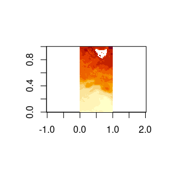

```r
mm <- matrix(vapour_read_raster(f, native = TRUE)[[1]],
      vapour_raster_info(f)$dimXY)
mm[mm < -1e6] <- NA
image(mm[,ncol(mm):1], asp = 2)
```

An example of using this facility interactively is in lazyraster.

## OGRSQL

SQL is available for general GDAL vector data.

```r
## note, this code assumes OGRSQL dialect
current_dialect <- Sys.getenv("vapour.sql.dialect")
Sys.unsetenv("vapour.sql.dialect")  ## ensure that default dialect is used
## (in this case it's 'OGRSQL' but we only want to record the state and reset after)
## later on, when done do Sys.setenv(vapour.sql.dialect = current_dialect)


vapour_read_fields(mvfile, sql = "SELECT NAME, PLAN_REF FROM list_locality_postcode_meander_valley WHERE POSTCODE < 7291")
```

```
#> $NAME
#>  [1] "Frankford"          "Bridgenorth"        "Summerhill"
#>  [4] "Blackstone Heights" "Lake St Clair"      "Trevallyn"
#>  [7] "Riverside"          "Hadspen"            "Travellers Rest"
#> [10] "Prospect Vale"
#>
#> $PLAN_REF
#>  [1] "CPR5142" "CPR5140" "CPR5150" "CPR5326" "CPR5570" "CPR5155" "CPR5140"
#>  [8] "CPR5329" "CPR5326" "CPR5325"
```

```r
vapour_read_fields(mvfile, sql = "SELECT NAME, PLAN_REF, FID FROM list_locality_postcode_meander_valley WHERE POSTCODE = 7306")
```

```
#> $NAME
#> [1] "Cradle Mountain" "Mount Roland"    "Middlesex"       "Lower Beulah"
#>
#> $PLAN_REF
#> [1] "CPR5363" "CPR5359" "CPR5362" "CPR5361"
#>
#> $FID
#> [1] 20 31 36 45
```

Also note that FID is a special row number value, to be used a as general facility for selecting by structural row. This FID is driver-dependent, it can be 0- or 1-based, or completely arbitrary.

Variously, drivers (GDAL’s formats) are 0- or 1- based with the FID. Others (such as OSM) are arbitrary, and have non-sequential (and presumably persistent) FID values.

```r
library(vapour)
file0 <- "list_locality_postcode_meander_valley.tab"
mvfile <- system.file("extdata/tab", file0, package="vapour")
layer <- gsub(".tab$", "", basename(mvfile))
## get the number of features by FID (DISTINCT should be redundant here)
vapour_read_fields(mvfile, sql = sprintf("SELECT COUNT(DISTINCT FID) AS nfeatures FROM %s", layer))
```

```
#> $nfeatures
#> [1] 58
```

```r
## note how TAB is 1-based
vapour_read_fields(mvfile, sql = sprintf("SELECT COUNT(*) AS n FROM %s WHERE FID < 2", layer))
```

```
#> $n
#> [1] 1
```

```r
## but SHP is 0-based
shp <- system.file("extdata/point.shp", package="vapour")
vapour_read_fields(shp, sql = sprintf("SELECT COUNT(*) AS n FROM %s WHERE FID < 2", "point"))
```

```
#> $n
#> [1] 2
```

See https://gdal.org/en/stable/user/ogr_sql_dialect.html

Now we are done with our SQL, so in case something else was using `current_dialect`, restore it.

```r
Sys.setenv(vapour.sql.dialect = current_dialect)
```

There are many useful higher level operations that can be used with this. The simplest is the ability to use GDAL as a database-like connection to attribute tables.

# SQL Dialect

In earlier versions (pre 0.9.1) we couldn’t control the SQL dialect in use, so we variously had available ‘OGRSQL’ or ‘SQLITE’, or whatever native dialect the format defaults to. We couldn’t use ‘OGRSQL’ with a Geopackage, and neither could we use ‘SQLITE’ with a shapefile, MapInfo TAB, or ESRI file Geodatabase (these last three aren’t “real” databases so don’t have their own native SQL, and GDAL fills the gap with OGRSQL. Geopackage defaults to SQLITE, because that’s what it is built upon.

So for example.

```r
## good citizenry
current_dialect <- Sys.getenv("vapour.sql.dialect")
Sys.setenv(vapour.sql.dialect = "SQLITE")

## now we can use SQLITE dialect with TAB
vapour_read_fields(mvfile, sql = sprintf("SELECT st_area(GEOMETRY) AS area FROM %s LIMIT 1 ", layer))
```

```
#> $area
#> [1] 51713229
```

```r
## but with OGRSQL we need
Sys.setenv(vapour.sql.dialect = "OGRSQL")
vapour_read_fields(mvfile, sql = sprintf("SELECT OGR_GEOM_AREA AS area FROM %s LIMIT 1 ", layer))
```

```
#> $area
#> [1] 51713229
```

# GDAL information

Find the GDAL version and drivers available.

```r
vapour_gdal_version()
```

```
#> [1] "GDAL 3.13.0dev-a3b7b01d3e-dirty, released 2026/02/23 (debug build)"
```

```r
str(vapour_all_drivers())
```

```
#> List of 7
#>  $ driver : chr [1:204] "DERIVED" "GTI" "SNAP_TIFF" "GTiff" ...
#>  $ name   : chr [1:204] "Derived datasets using VRT pixel functions" "GDAL Raster Tile Index" "Sentinel Application Processing GeoTIFF" "GeoTIFF" ...
#>  $ vector : logi [1:204] FALSE FALSE FALSE FALSE FALSE FALSE ...
#>  $ raster : logi [1:204] TRUE TRUE TRUE TRUE TRUE TRUE ...
#>  $ create : logi [1:204] FALSE FALSE FALSE TRUE TRUE FALSE ...
#>  $ copy   : logi [1:204] FALSE FALSE FALSE TRUE TRUE FALSE ...
#>  $ virtual: logi [1:204] FALSE TRUE TRUE TRUE TRUE TRUE ...
```

Find the driver that will be used for a given data source.

```r
vapour_driver(mvfile)
```

```
#> [1] "MapInfo File"
```